# Simulations for Brownian Motion with the Langevin Equation

2025-08-22

# For one experiment, change over time

## 1. Distribution of Gaussian random numbers.

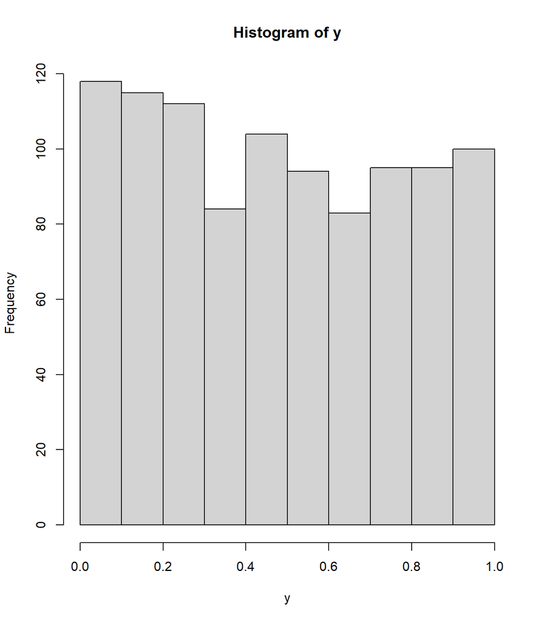

```r
y<-runif(1000)
hist(y)
```

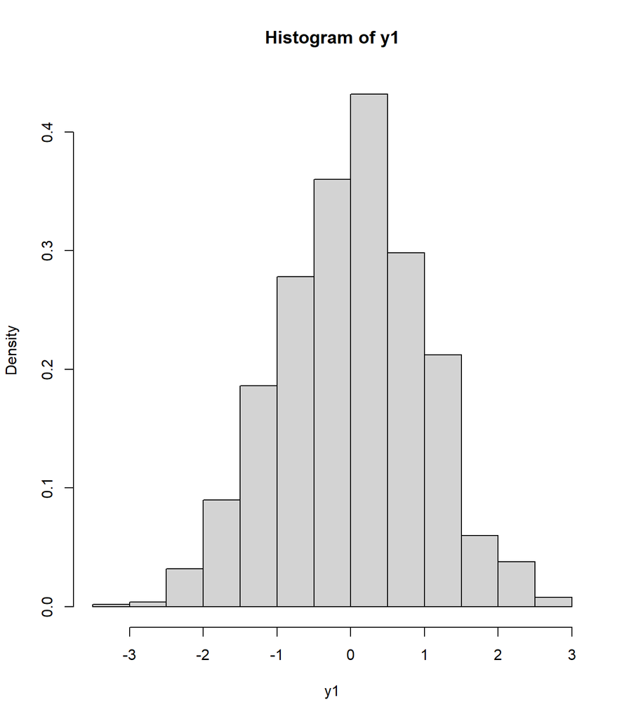

```r
y1<-rnorm(1000)

x=seq(-3,3,by=6/1000)

hist(y1, probability=TRUE)
```

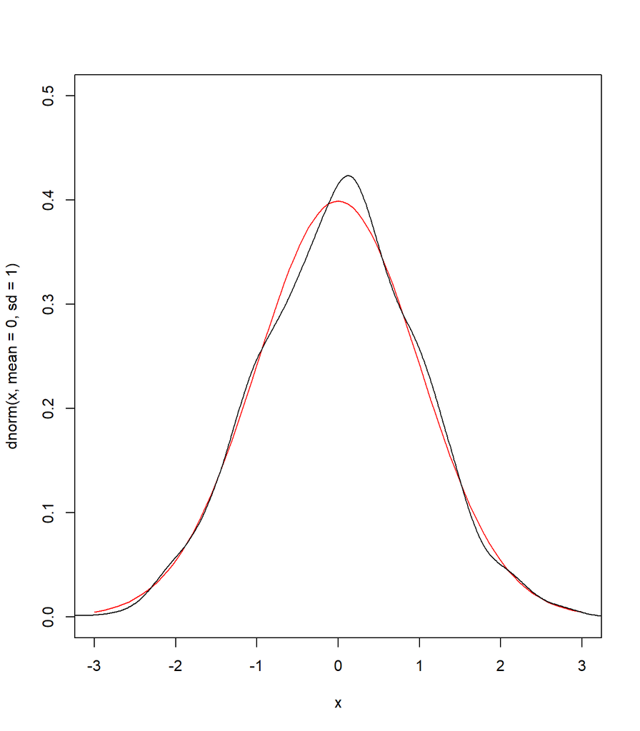

```r
curve(dnorm(x,mean=0,sd=1),xlim=c(-3,3), ylim=c(0,0.5), col='red')
lines(density(y1))
```

```r
shapiro.test(y1)
```

```
##
##  Shapiro-Wilk normality test
##
## data:  y1
## W = 0.99885, p-value = 0.7863
```

For an $\alpha > 0.05$ and $W\~1$ we can conclude that the randomly generated data for rnorm() follows a gaussian/normal as the function indicates distribution while the random numbers generation function runif doesn’t.

## 2. x(t) of different experiments with the same parameters.

• For $\gamma$ = 1 we can plot 100 different experiments with the code that follows:

```r
LE_function <- function(dt, t_finish, N, gamma){
  mass <- 1
  t <- seq(dt,t_finish, by=dt)

  N_steps <- as.integer(t_finish / dt)
  kbT_vec <- 1.0

  x <- matrix(0,N_steps,N)
  v <- matrix(0,N_steps,N)
  v_square <- matrix(0,N_steps,N)
  x_square <- matrix(0,N_steps,N)

  for  (i in 1:N){
    v[1,i] <- rnorm(1)

    D <- kbT_vec / gamma
    B_gj <- 1 / (1 + gamma * dt / (2 * mass))
    A_gj <- B_gj * (1 - gamma * dt / (2 * mass))
    stoch <- sqrt(2 * kbT_vec * gamma * dt)

    for (index_step in 2:N_steps) {
      W <- stoch * rnorm(1)
      x[index_step, i] <- x[index_step - 1,i] + B_gj * dt * v[index_step - 1, i] + (B_gj * dt / (2 * mass)) * W
      v[index_step, i] <- A_gj * v[index_step - 1, i ] + (B_gj / mass) * W
      v_square[index_step, i] <- ((index_step - 1) * v_square[index_step - 1, i] + v[index_step, i]^2) / index_step
      x_square[index_step, i] <- ((index_step - 1) * x_square[index_step - 1, i] + x[index_step, i]^2) / index_step
    }
  }
  return(data.frame(x=x, v=v, x2=x_square, v2=v_square,t))
}

x <- LE_function(0.001,20,100,1)[,1:100]
```

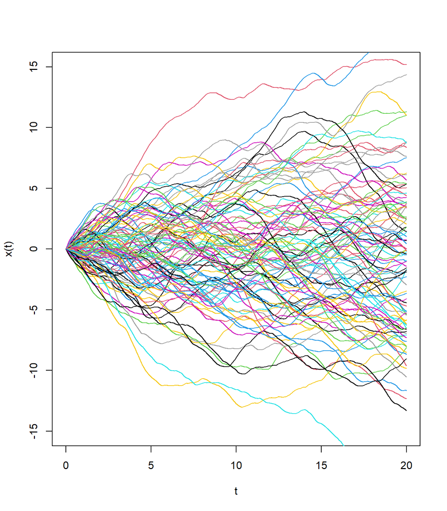

```r
plot(1, type='n', xlab='t', ylab='x(t)', xlim=c(0,20), ylim=c(-15,15), lty=1, lwd=1)
for (i in 1:100){
lines(x=seq(0.001,20,by=0.001), y=x[,i], col=i)
}
```

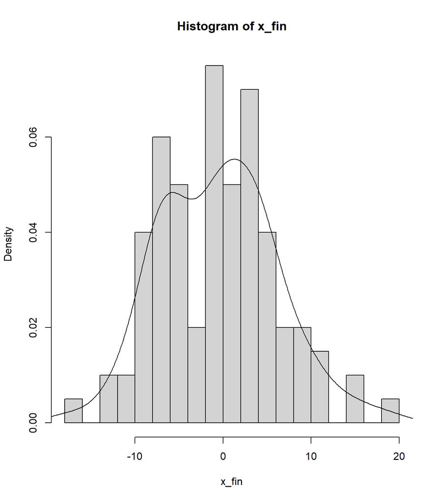

```r
x_fin <- t(x[20000,])

hist(x_fin, breaks=15, probability = TRUE)
lines(density(x_fin))
```

```r
shapiro.test(x_fin)
```

```
##
##  Shapiro-Wilk normality test
##
## data:  x_fin
## W = 0.98978, p-value = 0.6465
```

## 3. x(t) by changing the parameters:

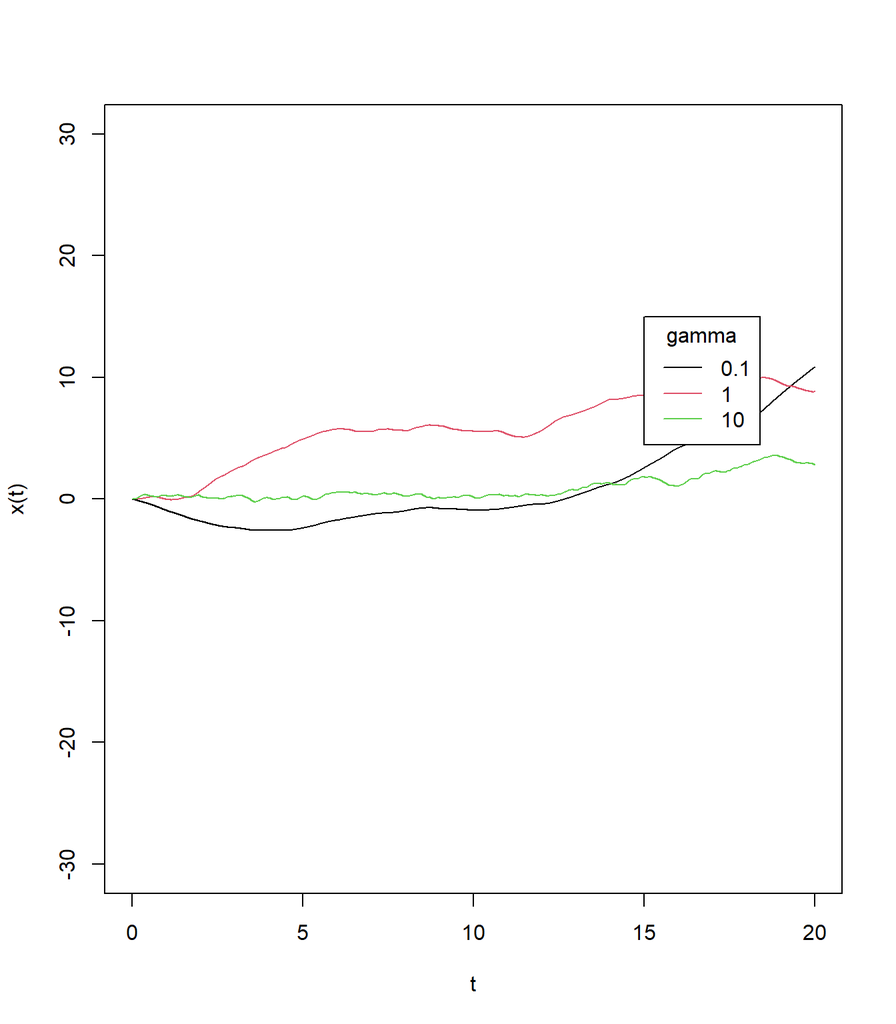

```r
x1 <- LE_function(0.001,20,1,0.1)[,1]
x2 <- LE_function(0.001,20,1,1)[,1]
x3 <- LE_function(0.001,20,1,10)[,1]
t <- LE_function(0.001,20,1,10)[,5]

plot(1, type='n', xlab='t', ylab='x(t)', xlim=c(0,20), ylim=c(-30,30), lty=1, lwd=1)
lines(x=t, y=x1, col=1)
lines(x=t, y=x2, col=2)
lines(x=t, y=x3, col=3)
legend(15,15,legend=c(0.1,1,10), col=c(1,2,3),lty=c(1,1), cex=1, title='gamma')
```

## 4. v(t) and its Gaussian distribution at the end of the simulation.

```r
v <- LE_function(0.001,2000,1,1)[,2]
```

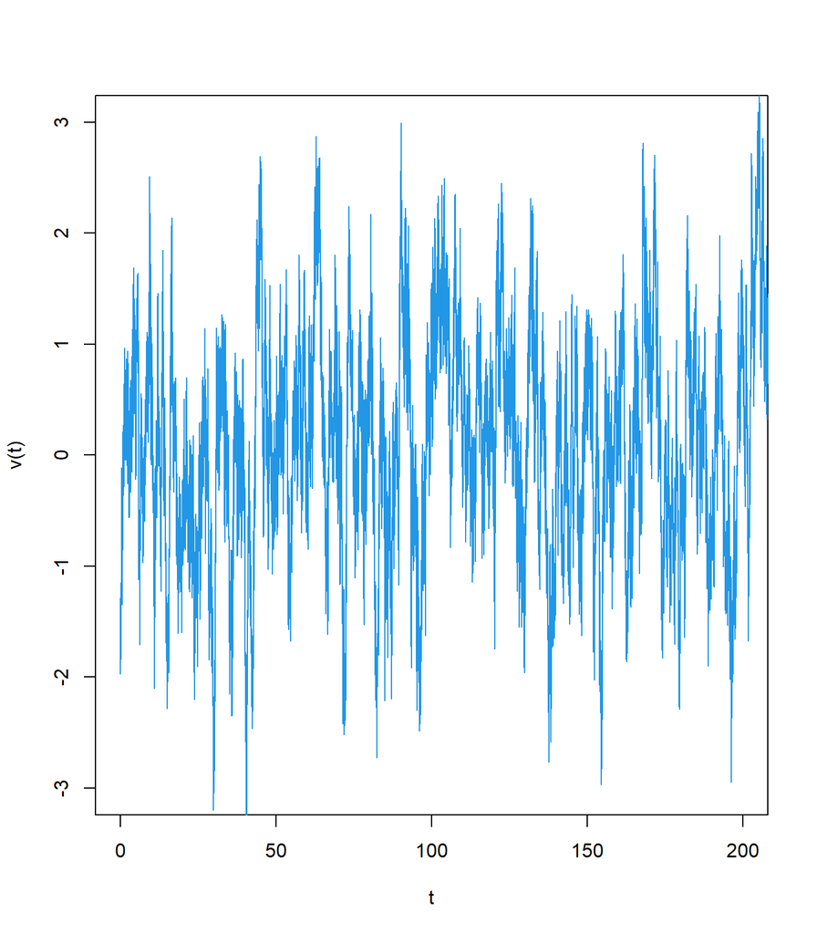

```r
plot(1, type='n', xlab='t', ylab='v(t)', ylim=c(-3,3), xlim=c(0,200), lty=1, lwd=1)
lines(x=LE_function(0.001,2000,1,1)$t, y=v, col=i)
```

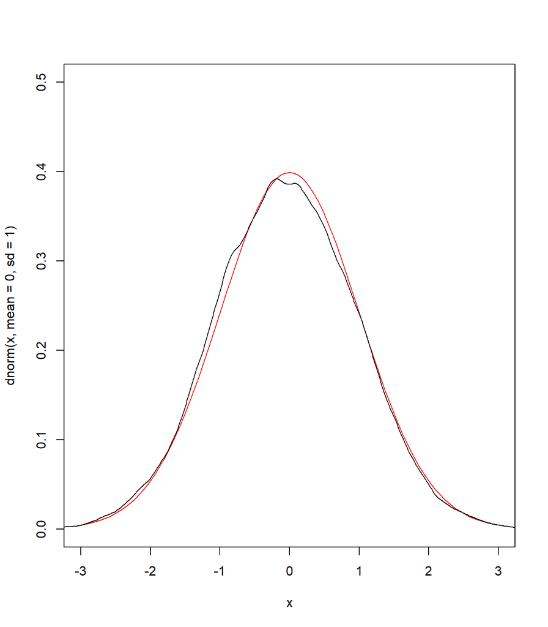

```r
curve(dnorm(x,mean=0,sd=1), xlim=c(-3,3), ylim=c(0,0.5), col='red')
lines(density(v),col=1)
```

```r
print(shapiro.test(sample(v, 5000)))
```

```
##
##  Shapiro-Wilk normality test
##
## data:  sample(v, 5000)
## W = 0.99936, p-value = 0.07325
```

For an $\alpha > 0.01$ and W~1 we can conclude that velocity follows a gaussian distribution.

## 5. $<\frac{1}{2}mv^2(t)>$ versus t plot changing the parameters showing:

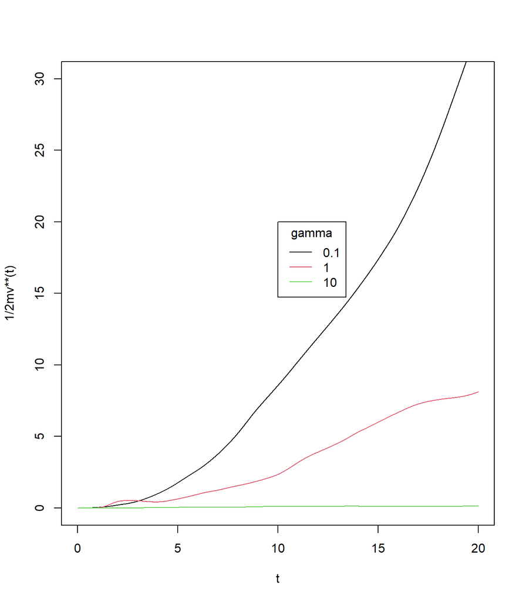

```r
v_square_1 <- LE_function(0.001,20,1,0.1)[,3]
v_square_2 <- LE_function(0.001,20,1,1)[,3]
v_square_3 <- LE_function(0.001,20,1,10)[,3]
t <- LE_function(0.001,20,1,10)[,5]

plot(1, type='n', xlab='t', ylab='1/2mv**(t)', ylim=c(0,30), xlim=c(0,20), lty=1, lwd=1)
lines(x=t, y=((1/2)*1*v_square_1), col=1)
lines(x=t, y=((1/2)*1*v_square_2), col=2)
lines(x=t, y=((1/2)*1*v_square_3), col=3)
legend(10,20,legend=c(0.1,1,10), col=c(1,2,3),lty=c(1,1), cex=1, title='gamma')
```

```r
mean((1/2)*1*v_square_1)
```

```
## [1] 10.64578
```

```r
mean((1/2)*1*v_square_2)
```

```
## [1] 3.308429
```

```r
mean((1/2)*1*v_square_3)
```

```
## [1] 0.07519264
```

# For a number of experiments equal or more than 200

## 1. $<\frac{1}{2}mv^2(t)>_{N_{exp}}$ versus t plot.

```r
v2_f <- function(dt, t_finish, N, gamma){
  mass <- 1
  t <- seq(dt,t_finish, by=dt)

  N_steps <- as.integer(t_finish / dt)
  kbT_vec <- 1.0

  x <- matrix(0,N_steps,N)
  v <- matrix(0,N_steps,N)
  v_square <- matrix(0,N_steps,N)
  x_square <- matrix(0,N_steps,N)

  for  (i in 1:N){
    v[1,i] <- rnorm(1)

    D <- kbT_vec / gamma
    B_gj <- 1 / (1 + gamma * dt / (2 * mass))
    A_gj <- B_gj * (1 - gamma * dt / (2 * mass))
    stoch <- sqrt(2 * kbT_vec * gamma * dt)

    for (index_step in 2:N_steps) {
      W <- stoch * rnorm(1)
      v[index_step,i] <- A_gj * v[index_step - 1,i] + (B_gj / mass) * W
      v_square[index_step, i] <- ((index_step - 1) * v_square[index_step - 1, i] + v[index_step, i]^2) / index_step
    }
  }
  return(data.frame(v2=v_square,t))
}
```

```r
v1_200 <- c()
for (i in 1:(20/0.1)){
v1_200 <- rbind(v1_200, mean(t(v2_f(0.1,20,200,0.1)[i,1:200])))
}

v2_200 <- c()
for (i in 1:(20/0.1)){
v2_200 <- rbind(v2_200, mean(t(v2_f(0.1,20,200,1)[i,1:200])))
}

v3_200 <- c()
for (i in 1:(20/0.1)){
v3_200 <- rbind(v3_200, mean(t(v2_f(0.1,20,200,10)[i,1:200])))
}
```

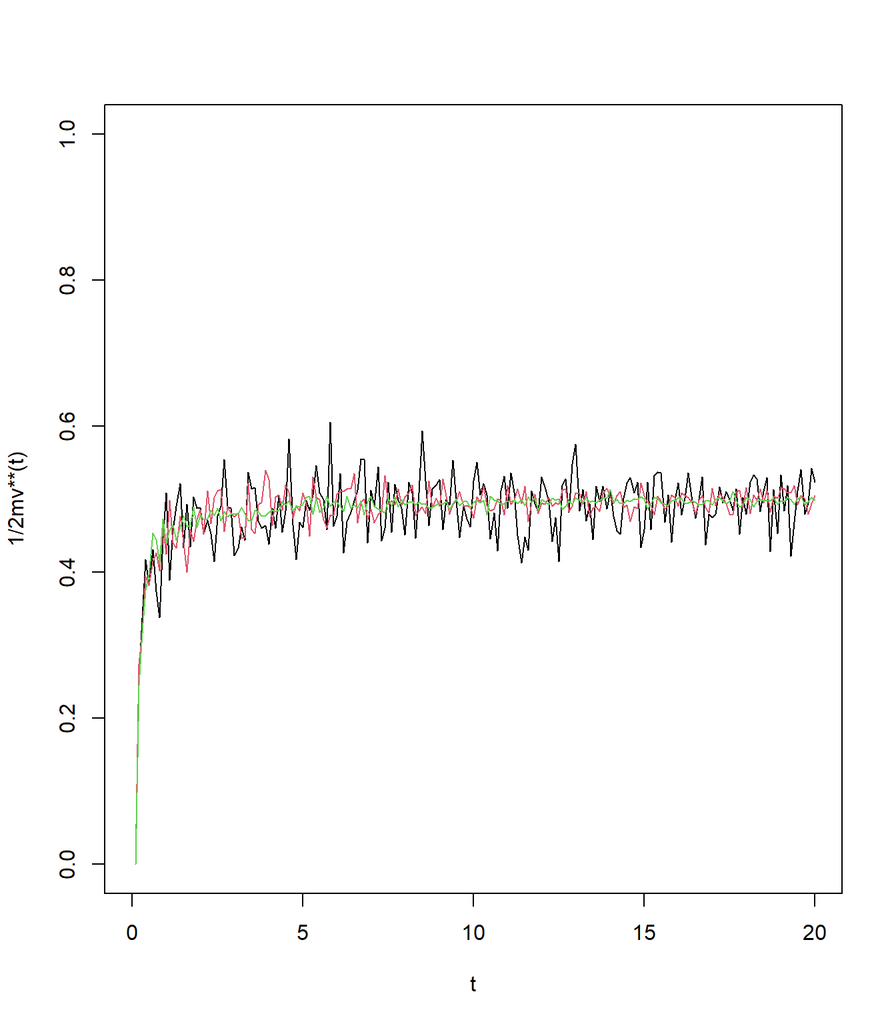

```r
plot(1, type='n', xlab='t', ylab='1/2mv**(t)', ylim=c(0,1), xlim=c(0,20), lty=1, lwd=1)
lines(x=seq(0.1,20,by=0.1), y=((1/2)*1*v1_200), col=1)
lines(x=seq(0.1,20,by=0.1), y=((1/2)*1*v2_200), col=2)
lines(x=seq(0.1,20,by=0.1), y=((1/2)*1*v3_200), col=3)
legend(10,20,legend=c(13,0.75,10), col=c(1,2,3),lty=c(1,1), cex=1, title='gamma')
```

## 2. $<x2(t)>_{N{exp}}$ versus t plot.

```r
x2_f <- function(dt, t_finish, N, gamma, kbT_vec){
  mass <- 1
  t <- seq(dt,t_finish, by=dt)

  N_steps <- as.integer(t_finish / dt)

  x <- matrix(0,N_steps,N)
  v <- matrix(0,N_steps,N)
  v_square <- matrix(0,N_steps,N)
  x_square <- matrix(0,N_steps,N)

  for  (i in 1:N){
    v[1,i] <- rnorm(1)

    D <- kbT_vec / gamma
    B_gj <- 1 / (1 + gamma * dt / (2 * mass))
    A_gj <- B_gj * (1 - gamma * dt / (2 * mass))
    stoch <- sqrt(2 * kbT_vec * gamma * dt)

    for (index_step in 2:N_steps) {
      W <- stoch * rnorm(1)
      x[index_step, i] <- x[index_step - 1,i] + B_gj * dt * v[index_step - 1, i] + (B_gj * dt / (2 * mass)) * W
      x_square[index_step, i] <- ((index_step - 1) * x_square[index_step - 1, i] + x[index_step, i]^2) / index_step
    }
  }
  return(data.frame(x2=x_square,t))
}
```

```r
x1_200 <- c()
for (i in 1:(20/0.1)){
x1_200 <- rbind(x1_200, mean(t(x2_f(0.1,20,200,0.1,0.1)[i,1:200])))
}

x2_200 <- c()
for (i in 1:(20/0.1)){
x2_200 <- rbind(x2_200, mean(t(x2_f(0.1,20,200,1,0.1)[i,1:200])))
}

x3_200 <- c()
for (i in 1:(20/0.1)){
x3_200 <- rbind(x3_200, mean(t(x2_f(0.1,20,200,10,0.1)[i,1:200])))
}
```

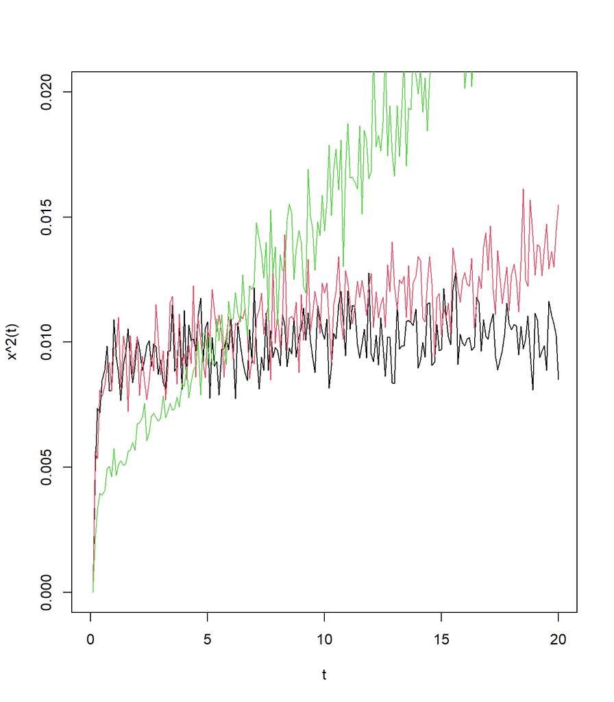

```r
plot(1, type='n', xlab='t', ylab='x^2(t)', ylim=c(0,0.02), xlim=c(0,20), lty=1, lwd=1)
lines(x=seq(0.1,20,by=0.1), y=(x1_200), col=1)
lines(x=seq(0.1,20,by=0.1), y=(x2_200), col=2)
lines(x=seq(0.1,20,by=0.1), y=(x3_200), col=3)
legend(10,20,legend=c(0,0.015,10), col=c(1,2,3),lty=c(1,1), cex=1, title='gamma')
```

## 3. The distribution of the displacements is Gaussian at “any” time, three examples:

```r
x <- LE_function(0.1,20,200,1)[,1:200]
```

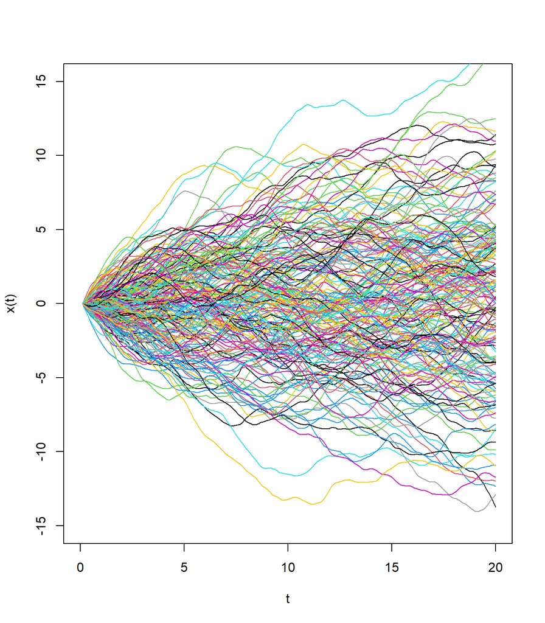

```r
plot(1, type='n', xlab='t', ylab='x(t)', xlim=c(0,20), ylim=c(-15,15), lty=1, lwd=1)
for (i in 1:200){
lines(x=LE_function(0.1,20,1,1)$t, y=x[,i], col=i)
}
```

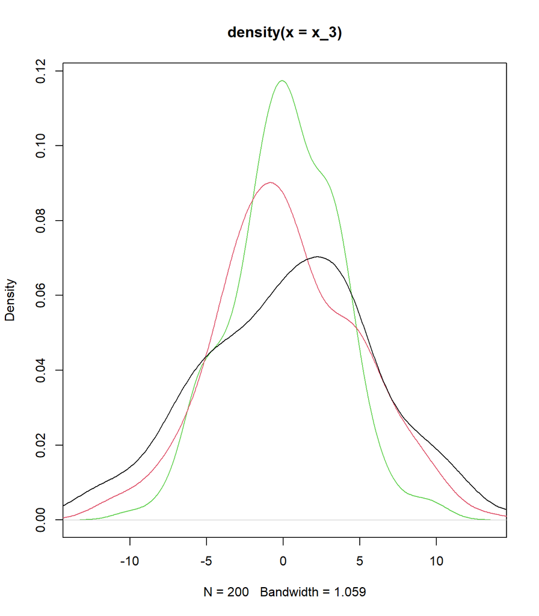

```r
x_1 <- t(x[200,])
x_2 <- t(x[133,])
x_3 <- t(x[70,])

plot(density(x_3), col=3)
lines(density(x_2), col=2)
lines(density(x_1), col=1)
```

```r
shapiro.test(x_1)
```

```
##
##  Shapiro-Wilk normality test
##
## data:  x_1
## W = 0.99442, p-value = 0.6642
```

```r
shapiro.test(x_2)
```

```
##
##  Shapiro-Wilk normality test
##
## data:  x_2
## W = 0.99353, p-value = 0.533
```

```r
shapiro.test(x_3)
```

```
##
##  Shapiro-Wilk normality test
##
## data:  x_3
## W = 0.99443, p-value = 0.6649
```

Distribution is gaussian every time since, the three samples are normally distributed.

## 4. Simulation with 200 particles for 2-dimensional dynamics.

• x(t) and y(t) for 200 particles

• $<x2(t)>_{N{exp}}$ for 200 particles.

• Showing the equipartition of energy $<E_c>=\frac{1}{2}k_{B}T$

```r
gamma=1
N=200
mass <- 1
dt=0.01
t_finish=20
t <- seq(0.01,20, by=0.01)

N_steps <- as.integer(20/0.01)
kbT_vec <- 1.0

x <- matrix(0,N_steps,N)
y <- matrix(0,N_steps,N)
v <- matrix(0,N_steps,N)
v_square <- matrix(0,N_steps,N)
x_square <- matrix(0,N_steps,N)
y_square <- matrix(0,N_steps,N)

for  (i in 1:N){
  v[1,i] <- rnorm(1)

  D <- kbT_vec / gamma
  B_gj <- 1 / (1 + gamma * dt / (2 * mass))
  A_gj <- B_gj * (1 - gamma * dt / (2 * mass))
  stoch <- sqrt(2 * kbT_vec * gamma * dt)

  for (index_step in 2:N_steps) {
    W <- stoch * rnorm(1)
    y[index_step, i] <- y[index_step - 1,i] + B_gj * dt * v[index_step - 1, i] + (B_gj * dt / (2 * mass)) * W
    x[index_step, i] <- x[index_step - 1,i] + B_gj * dt * v[index_step - 1, i] + (B_gj * dt / (2 * mass)) * W
    v[index_step, i] <- A_gj * v[index_step - 1, i ] + (B_gj / mass) * W
    v_square[index_step, i] <- ((index_step - 1) * v_square[index_step - 1, i] + v[index_step, i]^2) / index_step
    x_square[index_step, i] <- ((index_step - 1) * x_square[index_step - 1, i] + x[index_step, i]^2) / index_step
    y_square[index_step, i] <- ((index_step - 1) * y_square[index_step - 1, i] + y[index_step, i]^2) / index_step
  }
}
```

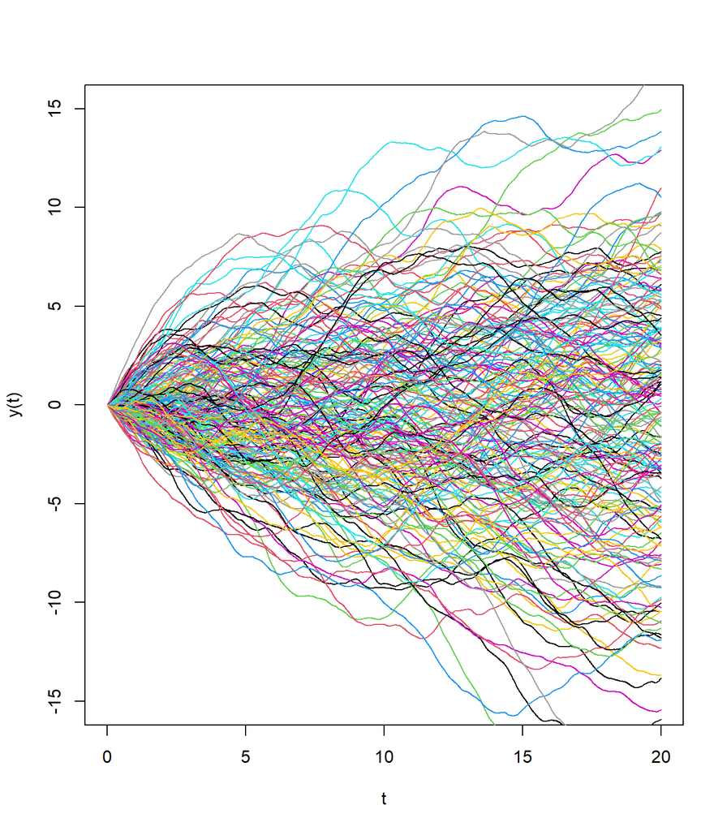

```r
plot(1, type='n', xlab='t', ylab='y(t)', xlim=c(0,20), ylim=c(-15,15), lty=1, lwd=1)
for (i in 1:200){
lines(x=t, y=y[,i], col=i)
}
```

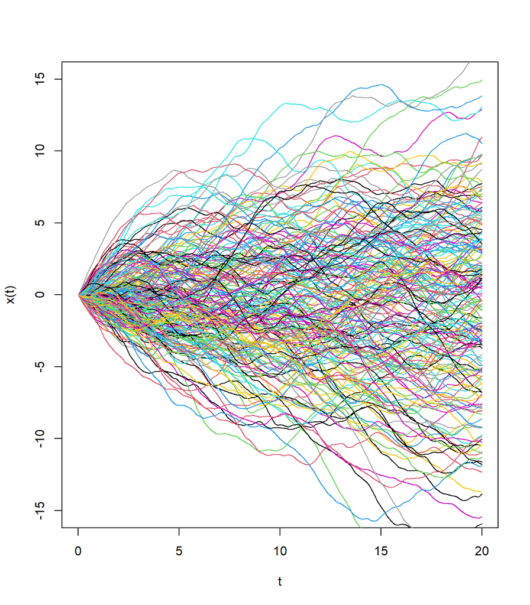

```r
plot(1, type='n', xlab='t', ylab='x(t)', xlim=c(0,20), ylim=c(-15,15), lty=1, lwd=1)
for (i in 1:200){
lines(x=t, y=x[,i], col=i)
}
```

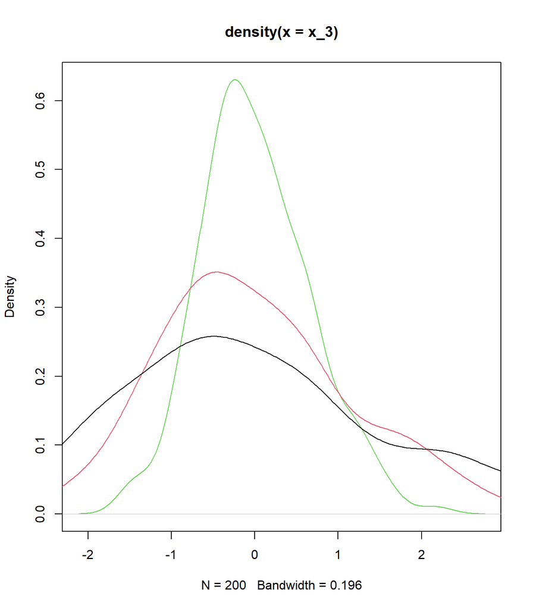

```r
x_1 <- t(x[200,])
x_2 <- t(x[133,])
x_3 <- t(x[70,])

plot(density(x_3), col=3)
lines(density(x_2), col=2)
lines(density(x_1), col=1)
```

```r
shapiro.test(x_1)
```

```
##
##  Shapiro-Wilk normality test
##
## data:  x_1
## W = 0.97993, p-value = 0.005816
```

```r
shapiro.test(x_2)
```

```
##
##  Shapiro-Wilk normality test
##
## data:  x_2
## W = 0.98457, p-value = 0.02752
```

```r
shapiro.test(x_3)
```

```
##
##  Shapiro-Wilk normality test
##
## data:  x_3
## W = 0.98847, p-value = 0.1061
```

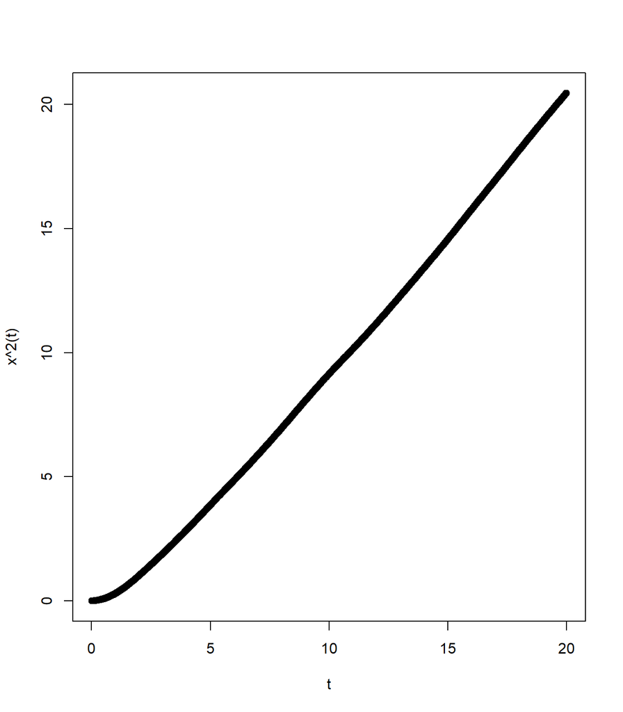

```r
x1_200_2d <- c()
for (i in 1:(20/0.01)){
x1_200_2d <- rbind(x1_200_2d, mean(t(x_square[i,])))
}

plot(x=t, y=x1_200_2d, ylab='x^2(t)', xlab='t')
```

```r
summary(lm(x1_200_2d~t))
```

```
##
## Call:
## lm(formula = x1_200_2d ~ t)
##
## Residuals:
##     Min      1Q  Median      3Q     Max
## -0.2773 -0.2332 -0.1398  0.1778  1.2840
##
## Coefficients:
##              Estimate Std. Error t value Pr(>|t|)
## (Intercept) -1.294664   0.013805  -93.78   <2e-16 ***
## t            1.062383   0.001195  888.94   <2e-16 ***
## ---
## Signif. codes:  0 '***' 0.001 '**' 0.01 '*' 0.05 '.' 0.1 ' ' 1
##
## Residual standard error: 0.3086 on 1998 degrees of freedom
## Multiple R-squared:  0.9975, Adjusted R-squared:  0.9975
## F-statistic: 7.902e+05 on 1 and 1998 DF,  p-value: < 2.2e-16
```

```r
v1_200_2d <- c()
for (i in 1:(20/0.01)){
v1_200_2d <- rbind(v1_200_2d, mean(t(v_square[i,])))
}
```

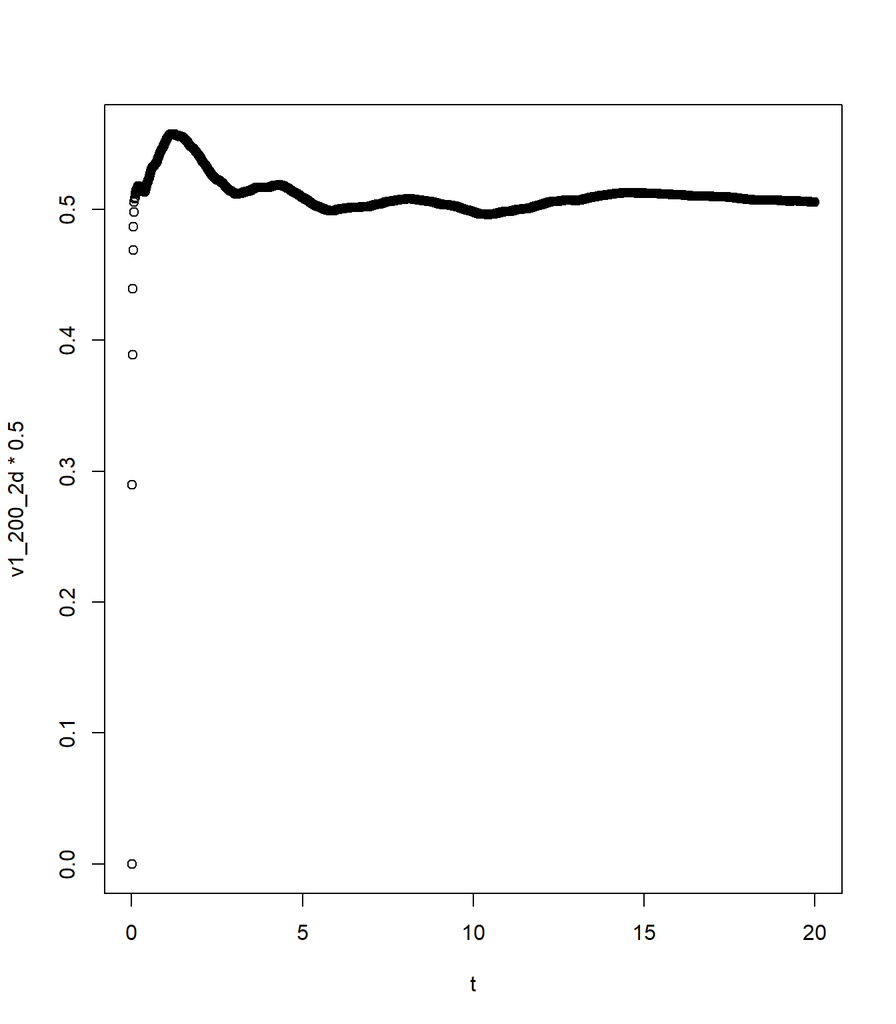

```r
plot(x=t, y=v1_200_2d*0.5)
```

```r
mean(v1_200_2d*0.5)
```

```
## [1] 0.5103446
```

There is an equipartition energy of $\frac{1}{2}k_{B}T$ and a value of kinetic energy of 0.5, which is near to the calculated mean.